# HW2 – Ying Zheng

Problem 1 (a)

```r
data(CRSPday)
crsp=CRSPday[,7]
crsp = as.numeric(crsp)
arima(crsp,order=c(1,0,0))
```

```
Call:
arima(x = crsp, order = c(1, 0, 0))

Coefficients:
         ar1  intercept
      0.0853      7e-04
s.e.  0.0198      2e-04

sigma^2 estimated as 5.973e-05:  log likelihood = 8706.18,  aic = -17406.37
```

```r
arima(crsp,order=c(2,0,0))
```

```
Call:
arima(x = crsp, order = c(2, 0, 0))

Coefficients:
         ar1      ar2  intercept
      0.0865  -0.0141      7e-04
s.e.  0.0199   0.0199      2e-04

sigma^2 estimated as 5.972e-05:  log likelihood = 8706.43,  aic = -17404.87
```

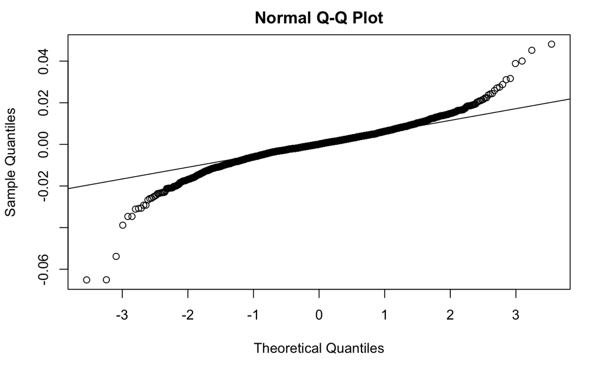

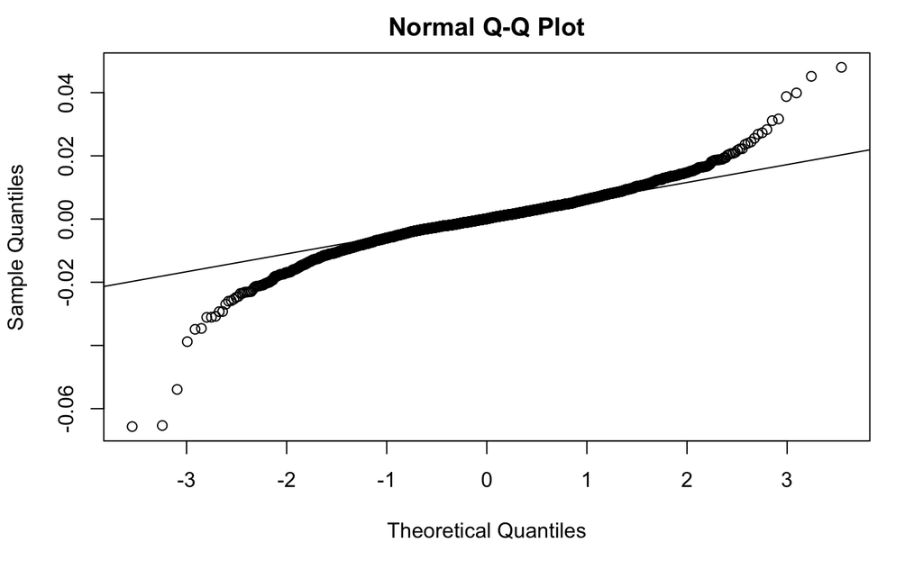

```r
AR1=arima(crsp,order=c(1,0,0))
AR2=arima(crsp,order=c(2,0,0))
qqnorm(AR1$residuals)
qqline(AR1$residuals)
qqnorm(AR2$residuals)

qqline(AR2$residuals)
```

2. ACF of the residuals: correlations in residuals for further lags stil exist, indicated by siginificant acf of AR(1) with lag greater than 1 and siginificant acf of AR(2) with lag greater than 2.

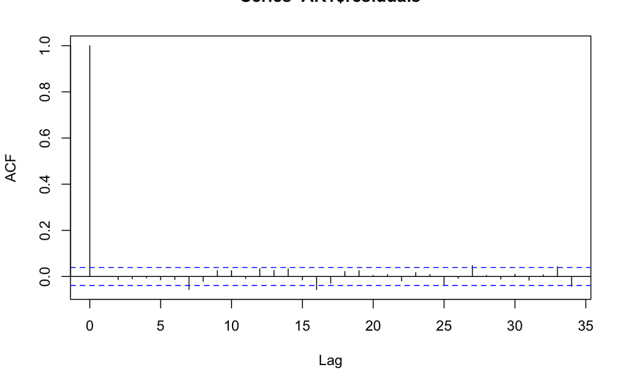

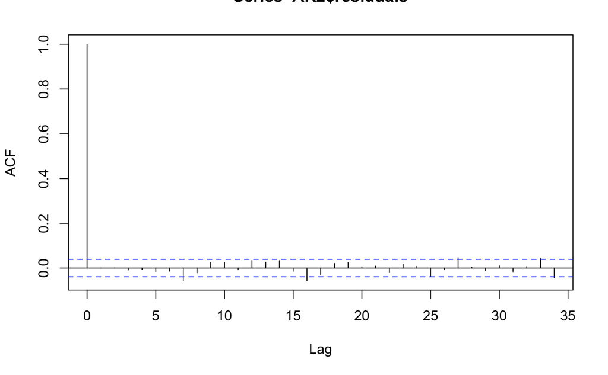

3. Sample ACF for the data VS. the fit ACF for the model: sample ACF and fitted ACF are almost the same.

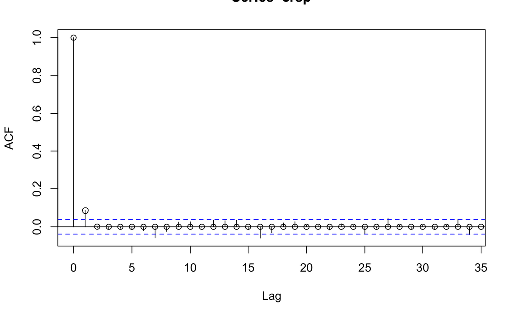

```r
acf(crsp)
fit.acf1=ARMAacf(ma=AR1$coef,lag.max=35)
points(0:35,fit.acf1)
fit.acf1
```

```
           0            1            2            3            4            5            6            7            8
1.0000000000 0.0847430537 0.0006739191 0.0000000000 0.0000000000 0.0000000000 0.0000000000 0.0000000000 0.0000000000
           9           10           11           12           13           14           15           16           17
0.0000000000 0.0000000000 0.0000000000 0.0000000000 0.0000000000 0.0000000000 0.0000000000 0.0000000000 0.0000000000
          18           19           20           21           22           23           24           25           26
0.0000000000 0.0000000000 0.0000000000 0.0000000000 0.0000000000 0.0000000000 0.0000000000 0.0000000000 0.0000000000
          27           28           29           30           31           32           33           34           35
0.0000000000 0.0000000000 0.0000000000 0.0000000000 0.0000000000 0.0000000000 0.0000000000 0.0000000000 0.0000000000
```

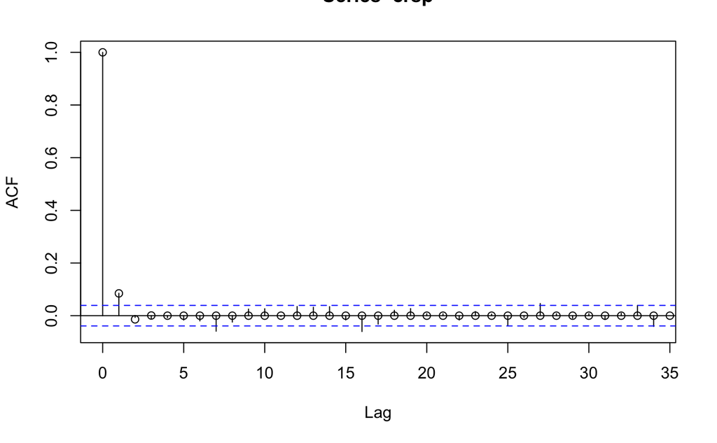

```r
acf(crsp)
fit.acf2=ARMAacf(ma=AR2$coef,lag.max=35)
points(0:35,fit.acf2)
```

```r
fit.acf2
```

```
            0             1             2             3             4             5             6             7
 1.0000000000  0.0846376279 -0.0139405611  0.0006731019  0.0000000000  0.0000000000  0.0000000000  0.0000000000
            8             9            10            11            12            13            14            15
 0.0000000000  0.0000000000  0.0000000000  0.0000000000  0.0000000000  0.0000000000  0.0000000000  0.0000000000
           16            17            18            19            20            21            22            23
 0.0000000000  0.0000000000  0.0000000000  0.0000000000  0.0000000000  0.0000000000  0.0000000000  0.0000000000
           24            25            26            27            28            29            30            31
 0.0000000000  0.0000000000  0.0000000000  0.0000000000  0.0000000000  0.0000000000  0.0000000000  0.0000000000
           32            33            34            35
 0.0000000000  0.0000000000  0.0000000000  0.0000000000
```

```r
Box.test(AR1$residuals,lag=20,fitdf=1, type="Ljung-Box")
```

```
    Box-Ljung test

data:  AR1$residuals
X-squared = 35.51, df = 19, p-value = 0.01212
```

```r
Box.test(AR2$residuals,lag=20,fitdf=2,type="Ljung-Box")
```

```
    Box-Ljung test

data:  AR2$residuals
X-squared = 34.53, df = 18, p-value = 0.01083
```

5. Value of AICc for each of the models: since AIC is slightly smaller for AR(1), we prefer AR(1) in this case.

```r
print(AR1$aic)
```

```
[1] -17406.37
```

```r
print(AR2$aic)
```

```
[1] -17404.87
```

Problem 1 (b)

```r
CI
```

```
[1] 0.046492 0.124108
```

Problem 2

```r
auto.arima(crsp,max.q=0,approximation=F)
```

```
Series: crsp
ARIMA(1,0,0) with non-zero mean

Coefficients:
         ar1   mean
      0.0853  7e-04
s.e.  0.0198  2e-04

sigma^2 estimated as 5.978e-05:  log likelihood=8706.18
AIC=-17406.37   AICc=-17406.36   BIC=-17388.86
```

```r
auto.arima(crsp,max.q=0,approximation=T)
```

```
Series: crsp
ARIMA(2,0,0) with non-zero mean

Coefficients:
         ar1      ar2   mean
      0.0865  -0.0141  7e-04
s.e.  0.0199   0.0199  2e-04

sigma^2 estimated as 5.979e-05:  log likelihood=8706.43
AIC=-17404.87   AICc=-17404.85   BIC=-17381.53
```

Based on AIC, when we set approximation to be false, AR(1) is the best AR(p) model. However, if we set approximation to be true, the result differs. AR(2) is the best model for AR(p) when approximaxion is true.